# Case Study

Deshpande, Vedant Sunil

6/19/2021

### Include required packages

```r
library(ggplot2)
library(dplyr)
library(patchwork)
library(leaps)
library(glmnet)
library(rpart)
library(rpart.plot)
library(ROCR)
library(boot)
library(faraway)
library(tidyr)
```

# 1. Boston Housing Data

```r
# Load the dataset
library(MASS)
boston <- data(Boston); #this data is in MASS package
colnames(Boston)
```

## 1.1 Start with exploratory data analysis. Repeat linear regression as in HW2.

```r
# Column structure
str(Boston)
```

```r
# Summary statistics
summary(Boston)
count(Boston,chas)
```

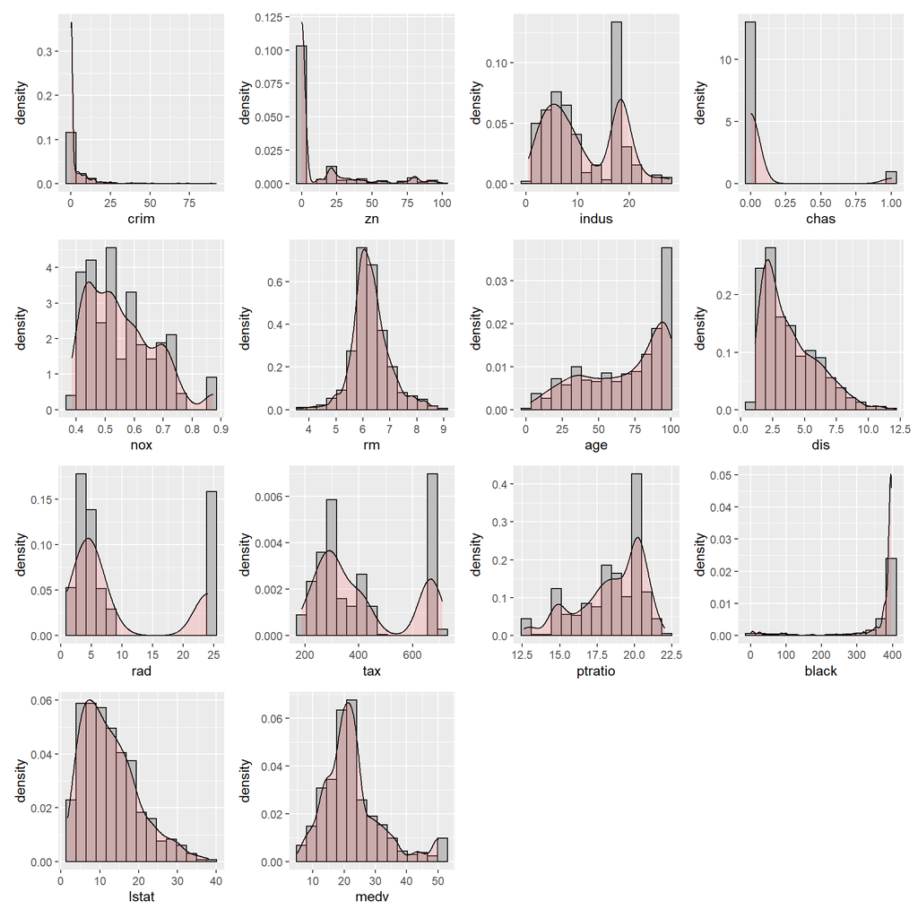

```r
# Histogram and density plots
par(mfrow = c(1,3))
h1 <- ggplot(Boston, aes(x=crim)) +
            geom_histogram(aes(y=..density..), color='black', fill = 'grey',bins = 15) +
            geom_density(alpha = 0.2, fill = "#FF6666")
h2 <- ggplot(Boston, aes(x=zn)) +
            geom_histogram(aes(y=..density..), color='black', fill = 'grey',bins = 15) +
            geom_density(alpha = 0.2, fill = "#FF6666")
h3 <- ggplot(Boston, aes(x=indus)) +
            geom_histogram(aes(y=..density..), color='black', fill = 'grey', bins = 15) +
            geom_density(alpha = 0.2, fill = "#FF6666")
h4 <- ggplot(Boston, aes(x=chas)) +
            geom_histogram(aes(y=..density..), color='black', fill = 'grey', bins = 15) +
            geom_density(alpha = 0.2, fill = "#FF6666")
h5 <- ggplot(Boston, aes(x=nox)) +
            geom_histogram(aes(y=..density..), color='black', fill = 'grey', bins = 15) +
            geom_density(alpha = 0.2, fill = "#FF6666")
h6 <- ggplot(Boston, aes(x=rm)) +
            geom_histogram(aes(y=..density..), color='black', fill = 'grey', bins =15) +
            geom_density(alpha = 0.2, fill = "#FF6666")
h7 <- ggplot(Boston, aes(x=age)) +
            geom_histogram(aes(y=..density..), color='black', fill = 'grey', bins = 15) +
            geom_density(alpha = 0.2, fill = "#FF6666")
h8 <- ggplot(Boston, aes(x=dis)) +
            geom_histogram(aes(y=..density..), color='black', fill = 'grey', bins = 15) +
            geom_density(alpha = 0.2, fill = "#FF6666")
h9 <- ggplot(Boston, aes(x=rad)) +
            geom_histogram(aes(y=..density..), color='black', fill = 'grey', bins = 15) +
            geom_density(alpha = 0.2, fill = "#FF6666")
h10 <- ggplot(Boston, aes(x=tax)) +
            geom_histogram(aes(y=..density..), color='black', fill = 'grey', bins = 15) +
            geom_density(alpha = 0.2, fill = "#FF6666")
h11 <- ggplot(Boston, aes(x=ptratio)) +
            geom_histogram(aes(y=..density..), color='black', fill = 'grey', bins = 15) +
            geom_density(alpha = 0.2, fill = "#FF6666")
h12 <- ggplot(Boston, aes(x=black)) +
            geom_histogram(aes(y=..density..), color='black', fill = 'grey', bins = 15) +
            geom_density(alpha = 0.2, fill = "#FF6666")
h13 <- ggplot(Boston, aes(x=lstat)) +
            geom_histogram(aes(y=..density..), color='black', fill = 'grey', bins = 15) +
            geom_density(alpha = 0.2, fill = "#FF6666")
h14 <- ggplot(Boston, aes(x=medv)) +
            geom_histogram(aes(y=..density..), color='black', fill = 'grey', bins = 15) +
            geom_density(alpha = 0.2, fill = "#FF6666")
h1 + h2 + h3 + h4 + h5 + h6 + h7 + h8 + h9 + h10 + h11 + h12 + h13 + h14
```

```r
# Convert categorical variable(s) to factor
Boston$chas <- as.factor(Boston$chas)

# Split data in to train and test samples (80-20)
set.seed(13748683)
sample_index <- sample(nrow(Boston),nrow(Boston)*0.80)
boston_train <- Boston[sample_index,]
boston_test <- Boston[-sample_index,]
```

```r
# Fit Linear Regression model
model_lm <- lm(medv~.,boston_train)
summary(model_lm)
```

```r
# MSE
pred_lm <- predict(model_lm)
MSE <- mean((boston_train$medv - pred_lm)**2)
MSE
```

## 1.2 As in HW2, find a best model using linear regression with AIC and BIC and LASSO variable selection. Report model mean squared error (model MSE).

```r
# Defining a null model stepwise selection
model_lm_n <- lm(medv~1,boston_train)
```

```r
# Stepwise selection using AIC
model_lm_aic <- step(model_lm_n,scope=list(lower=model_lm_n, upper=model_lm),direction='both')
```

```r
# Model MSE
pred_lm_aic <- predict(model_lm_aic)
MSE <- mean((boston_train$medv - pred_lm_aic)**2)
MSE
summary(model_lm_aic)
```

```r
# Stepwise selection using BIC
model_lm_bic <- step(model_lm_n,scope=list(lower=model_lm_n, upper=model_lm),direction='both', k=log(nrow(boston_train)))
```

```r
# Model MSE
pred_bic <- predict(model_lm_bic)
MSE <- mean((boston_train$medv - pred_bic)**2)
MSE
summary(model_lm_bic)
```

```r
# LASSO variable selection
lasso_fit <- glmnet(x = as.matrix(Boston[, -c(which(colnames(Boston)=='medv'))]), y = Boston$medv, alpha = 1)
```

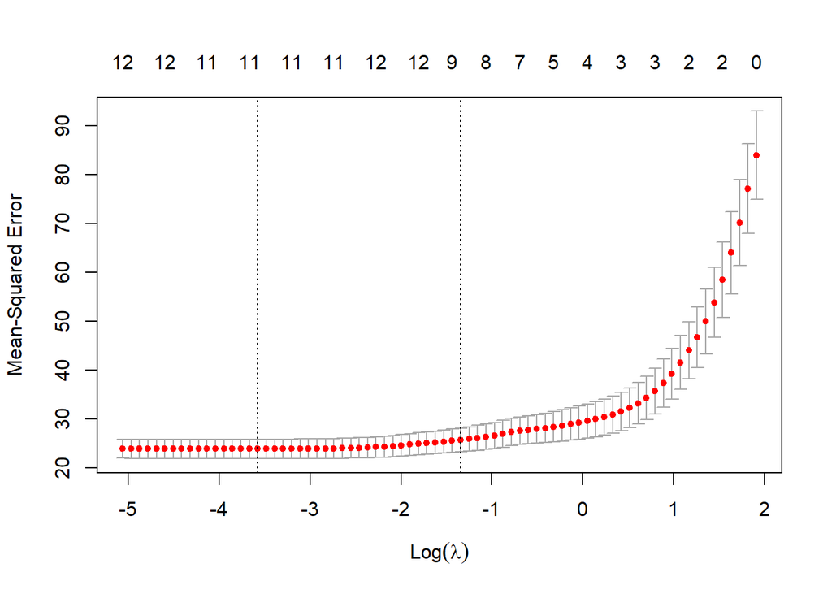

```r
# Use 5-fold cross validation to pick lambda
cv_lasso_fit <- cv.glmnet(x = data.matrix(Boston[, -c(which(colnames(Boston)=='medv'))]), y = Boston$medv, alpha = 1, nfolds = 5)
plot(cv_lasso_fit)
```

```r
cv_lasso_fit$lambda.min
```

```r
# LASSO variable selection using optimum lambda
coef(lasso_fit, s= cv_lasso_fit$lambda.min)
```

```r
# Fit model using LASSO recommended variables
lasso_lm <- lm(medv ~ crim + zn + chas + nox + rm + dis + rad + tax + ptratio + black + lstat, boston_train)
summary(lasso_lm)
```

```r
# Predicting data using optimum lambda
pred_cv <- predict(lasso_fit, data.matrix(Boston[, -c(which(colnames(Boston)=='medv'))]), s = cv_lasso_fit$lambda.min)
MSE <- mean((Boston$medv-pred_cv)**2)
MSE
```

```r
# Model MSE
pred_lasso <- predict(lasso_lm)
MSE <- mean((boston_train$medv - pred_lasso)**2)
MSE
summary(lasso_lm)
```

```r
# Final model
# We are going ahead with the LASSO model, since it is similar to AIC recommended one
model_final <- lm(medv ~ crim + zn + chas + nox + rm + dis + rad + tax + ptratio + black + lstat,boston_train)
```

## 1.3 Test the out-of-sample performance. Using final linear model built from (i) on the 80% of original data, test with the remaining 20% testing data. Report out-of-sample model MSPE etc.

```r
# Predicting data using model built in (i)
pred_test_f <- predict(model_final,boston_test)
MSPE <- mean((boston_test$medv-pred_test_f)**2)
MSPE
```

## 1.4 Cross validation. Use 5-fold cross validation. (Please use cv.glm() function in R on the ORIGINAL 100% data.) Does (iv) yield similar answer as (iii)? Please give specific CV score (MSE) and your reason.

```r
# Fit a model wit full data using variables recommended above
model_cv <- glm(medv ~ crim + zn + chas + nox + rm + dis + rad + tax + ptratio + black + lstat,data=Boston)
```

```r
# CV score (default = MSE)
set.seed(13748683)
cv.glm(data=Boston,glmfit = model_cv,K=5)$delta[2]
```

## 1.5 Fit a regression tree (CART) on the same data; repeat the above step (iii).

```r
# CART model
boston_rpart <- rpart(formula = medv ~ ., data = boston_train)
boston_rpart
```

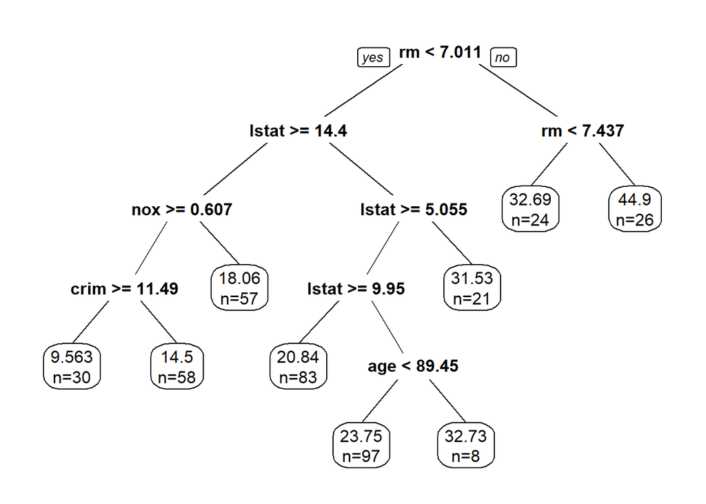

```r
# Plotting the tree
prp(boston_rpart,digits = 4, extra = 1)
```

```r
# MSPE
pred_tree <- predict(boston_rpart,boston_test)
MSPE <- mean((boston_test$medv-pred_tree)**2)
MSPE
```

## 1.6 What do you find comparing CART to the linear regression model fits from HW2?

## 1.7 Now repeat previous steps for another random sample (that is, to draw another training data set with 80% of original data, and the rest 20% as testing). Do you get similar results? What’s your conclusion?

```r
# Creating new train and test splits using same proportions
set.seed(1000)
sample_index <- sample(nrow(Boston),nrow(Boston)*0.80)
boston_train <- Boston[sample_index,]
boston_test <- Boston[-sample_index,]
```

### 1.7.1 Fit Linear Regression model

```r
model_lm2 <- lm(medv~.,boston_train)
summary(model_lm2)
```

```r
# Model MSE
pred_lm2 <- predict(model_lm2)
MSE <- mean((boston_train$medv - pred_lm2)**2)
MSE
```

### 1.7.2 Model selection

```r
# Fit null model
model_lm_n2 <- lm(medv~1,boston_train)
```

```r
# Stepwise selection using AIC
model_lm2_aic <- step(model_lm_n2,scope=list(lower=model_lm_n2, upper = model_lm2) , direction='both')
```

```r
# Model with AIC parameters
model_lm_aic2 <- lm(medv ~ lstat + rm + ptratio + dis + nox + chas + black + rad + crim + tax + zn, boston_train)
summary(model_lm_aic2)

# Model MSE
pred_lm_aic2 <- predict(model_lm_aic2)
MSE <- mean((boston_train$medv - pred_lm_aic2)**2)
MSE
```

```r
# Stepwise selection using BIC
model_lm2_bic <- step(model_lm_n2,scope=list(lower=model_lm_n2, upper = model_lm2) , direction='both', k=log(nrow(boston_train)))
```

```r
# Model with BIC parameters
model_lm_bic2 <- lm(medv ~ lstat + rm + ptratio + dis + nox + chas + black,boston_train)
summary(model_lm_bic2)

# Model MSE
pred_lm_bic2 <- predict(model_lm_bic2)
MSE <- mean((boston_train$medv - pred_lm_bic2)**2)
MSE
```

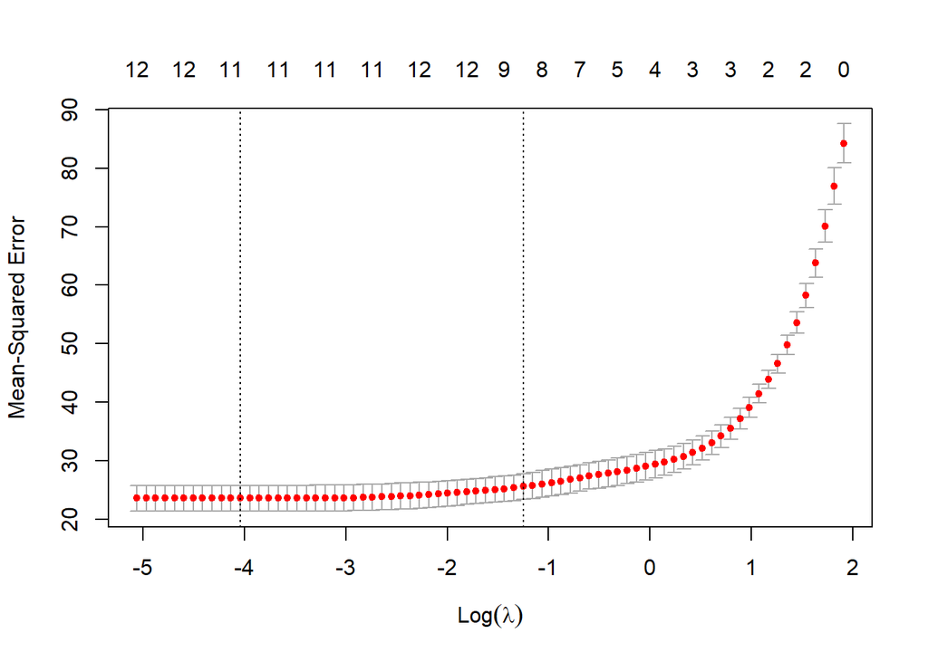

```r
# LASSO variable selection
lasso_fit2 <- glmnet(x = data.matrix(Boston[, -c( which( colnames(Boston)=='medv'))]), y = Boston$medv, alpha = 1)

# Use 5-fold cross validation to pick lambda
cv_lasso_fit <- cv.glmnet(x = data.matrix(Boston[, -c(which(colnames(Boston)=='medv'))]), y = Boston$medv, alpha = 1, nfolds = 5)
plot(cv_lasso_fit)
```

```r
cv_lasso_fit$lambda.min
```

```r
# LASSO variable selection using optimum lambda
coef(lasso_fit2, s= cv_lasso_fit$lambda.min)
```

```r
# Fit model using LASSO recommended variables
lasso_lm <- lm(medv ~ crim + zn + chas + nox + rm + dis + rad + tax + ptratio + black + lstat, boston_train)
summary(lasso_lm)
```

```r
# Model MSE
pred_lasso <- predict(lasso_lm)
MSE <- mean((boston_train$medv - pred_lasso)**2)
MSE
```

```r
# Final model
# We are going ahead with the LASSO model, since it is similar to AIC recommended one
model_final2 <- lm(medv ~ crim + zn + chas + nox + rm + dis + rad + tax + ptratio + black + lstat,boston_train)
```

### 1.7.3 Out-of-sample performance

```r
# Predicting data using model built in (1.7.1)
pred_test_f2 <- predict(model_final2,boston_test)
MSPE <- mean((boston_test$medv-pred_test_f2)**2)
MSPE
```

### 1.7.4 5-fold cross validation

```r
# Fit a model wit full data using variables recommended above
model_cv2 <- glm(medv ~ crim + zn + chas + nox + rm + dis + rad + tax + ptratio + black + lstat,data=Boston)
```

```r
# CV score (default = MSE)
cv.glm(data=Boston,glmfit = model_cv,K=5)$delta[2]
```

### 1.7.5 CART model

```r
# CART model
boston_rpart2 <- rpart(formula = medv ~ ., data = boston_train)
boston_rpart2
```

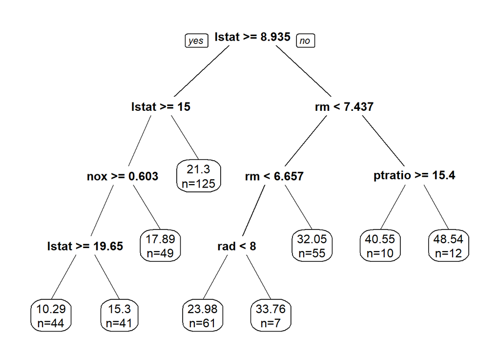

```r
# Plotting the tree
prp(boston_rpart2,digits = 4, extra = 1)
```

```r
# MSPE
pred_tree2 <- predict(boston_rpart2,boston_test)
MSPE <- mean((boston_test$medv-pred_tree2)**2)
MSPE
```

# 2. German Credit Scoring Data

```r
#Load the dataset:
german_credit = read.table("http://archive.ics.uci.edu/ml/machine-learning-databases/statlog/german/german.data")

#Assigning column names based on data dictionary
colnames(german_credit)=c("checking", "duration", "history", "purpose", "credit", "savings", "employment", "installment", "sex", "debtors", "residence", "property", "age", "other_inst", "housing", "existing_credits", "job", "liable", "phone", "foreign","target")

head(german_credit)
```

## 2.1 Start with exploratory data analysis. Repeat generalized linear regression as in HW3. Try different link functions (logistic, probit, complementary log-log link) and compare.

```r
# Converting categorical variables to factors
german_credit$checking <- as.factor(german_credit$checking)
german_credit$history <- as.factor(german_credit$history)
german_credit$purpose <- as.factor(german_credit$purpose)
german_credit$savings <- as.factor(german_credit$savings)
german_credit$employment <- as.factor(german_credit$employment)
german_credit$sex <- as.factor(german_credit$sex)
german_credit$debtors <- as.factor(german_credit$debtors)
german_credit$property <- as.factor(german_credit$property)
german_credit$other_inst <- as.factor(german_credit$other_inst)
german_credit$housing <- as.factor(german_credit$housing)
german_credit$job <- as.factor(german_credit$job)
german_credit$phone <- as.factor(german_credit$phone)
german_credit$foreign <- as.factor(german_credit$foreign)
german_credit$target <- as.factor(german_credit$target)
```

```r
# Summary statistics
summary(german_credit)
```

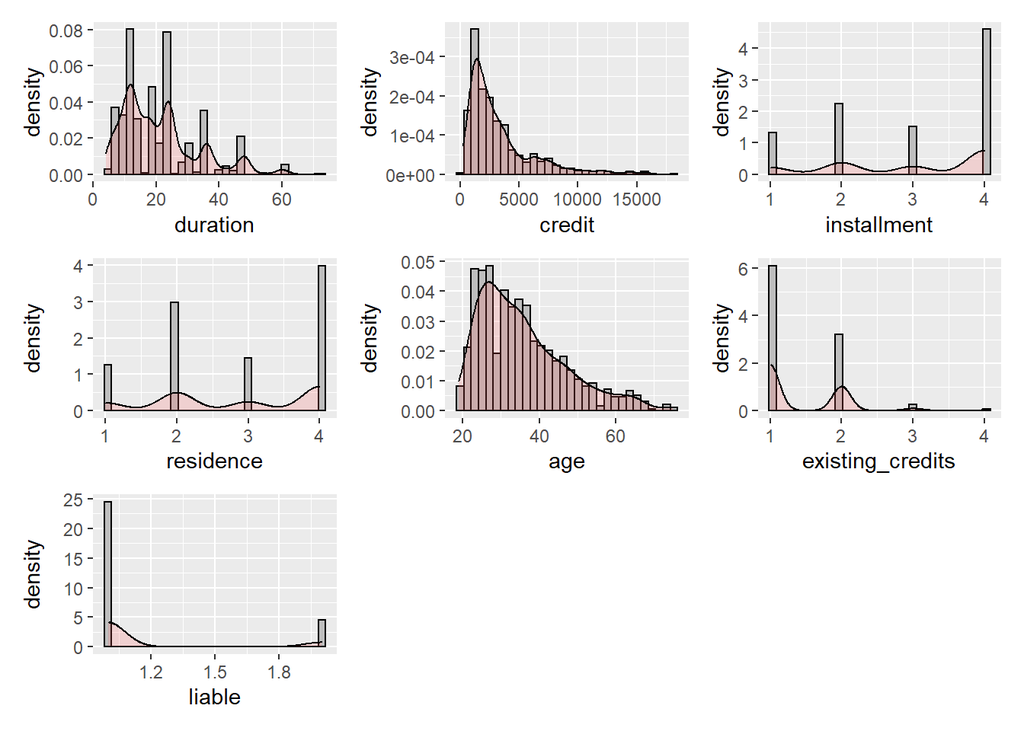

```r
# Histograms and density plots for continuous variables
par(mfrow = c(3,3))
h1 <- ggplot(german_credit, aes(x=duration)) +
            geom_histogram(aes(y=..density..), color='black', fill = 'grey') +
            geom_density(alpha = 0.2, fill = "#FF6666")
h2 <- ggplot(german_credit, aes(x=credit)) +
            geom_histogram(aes(y=..density..), color='black', fill = 'grey') +
            geom_density(alpha = 0.2, fill = "#FF6666")
h3 <- ggplot(german_credit, aes(x=installment)) +
            geom_histogram(aes(y=..density..), color='black', fill = 'grey') +
            geom_density(alpha = 0.2, fill = "#FF6666")
h4 <- ggplot(german_credit, aes(x=residence)) +
            geom_histogram(aes(y=..density..), color='black', fill = 'grey') +
            geom_density(alpha = 0.2, fill = "#FF6666")
h5 <- ggplot(german_credit, aes(x=age)) +
            geom_histogram(aes(y=..density..), color='black', fill = 'grey') +
            geom_density(alpha = 0.2, fill = "#FF6666")
h6 <- ggplot(german_credit, aes(x=existing_credits)) +
            geom_histogram(aes(y=..density..), color='black', fill = 'grey') +
            geom_density(alpha = 0.2, fill = "#FF6666")
h7 <- ggplot(german_credit, aes(x=liable)) +
            geom_histogram(aes(y=..density..), color='black', fill = 'grey') +
            geom_density(alpha = 0.2, fill = "#FF6666")

h1 + h2 + h3 + h4 + h5 + h6 + h7
```

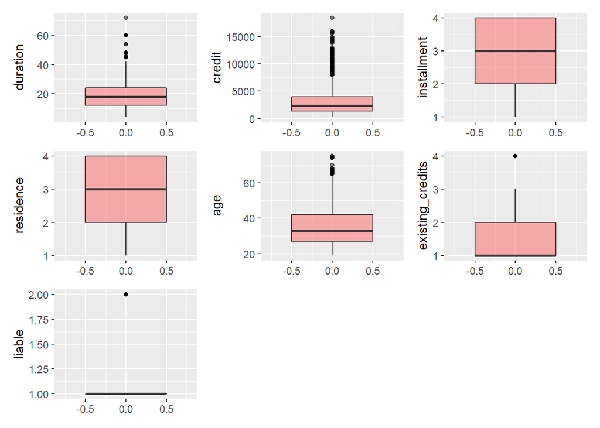

```r
# Box plots (continuous variables)
par(mfrow = c(3,3))

b1 <- ggplot(german_credit, aes(y=duration)) +
  geom_boxplot(fill='#FF6666',outlier.colour = 'black',width=1,alpha=0.5) + xlim(-0.8,0.8)
b2 <- ggplot(german_credit, aes(y=credit)) +
  geom_boxplot(fill='#FF6666',outlier.colour = 'black',width=1,alpha=0.5) + xlim(-0.8,0.8)
b3 <- ggplot(german_credit, aes(y=installment)) +
  geom_boxplot(fill='#FF6666',outlier.colour = 'black',width=1,alpha=0.5) + xlim(-0.8,0.8)
b4 <- ggplot(german_credit, aes(y=residence)) +
  geom_boxplot(fill='#FF6666',outlier.colour = 'black',width=1,alpha=0.5) + xlim(-0.8,0.8)
b5 <- ggplot(german_credit, aes(y=age)) +
  geom_boxplot(fill='#FF6666',outlier.colour = 'black',width=1,alpha=0.5) + xlim(-0.8,0.8)
b6 <- ggplot(german_credit, aes(y=existing_credits)) +
  geom_boxplot(fill='#FF6666',outlier.colour = 'black',width=1,alpha=0.5) + xlim(-0.8,0.8)
b7 <- ggplot(german_credit, aes(y=liable)) +
  geom_boxplot(fill='#FF6666',outlier.colour = 'black',width=1,alpha=0.5) + xlim(-0.8,0.8)

b1 + b2 + b3 + b4 + b5 + b6 + b7
```

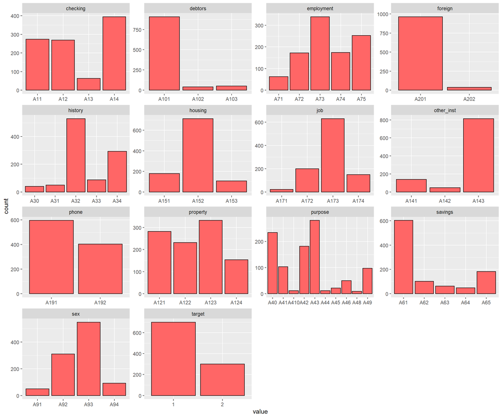

```r
# Bar chart for categorical variables
credit_cat = german_credit
credit_cat$duration = NULL
credit_cat$credit = NULL
credit_cat$installment = NULL
credit_cat$age = NULL
credit_cat$residence = NULL
credit_cat$existing_credits = NULL
credit_cat$liable = NULL
ggplot(gather(credit_cat), aes(value)) +
    geom_bar(fill = '#FF6666',color = 'black') +
    facet_wrap(~key,scales = 'free')
```

```r
# Split data in to train and test sample
set.seed(13748683)
index <- sample(nrow(german_credit),nrow(german_credit)*0.80)
credit_train = german_credit[index,]
credit_test = german_credit[-index,]
```

```r
# Fit generalized linear regression model - logit link
model_l <- glm(target~., family=binomial(link='logit'), data=credit_train)

# Fit generalized linear regression model - probit link
model_p <- glm(target~., family=binomial(link='probit'), data=credit_train)

# Fit generalized linear regression model - complementary log-log link
model_c <- glm(target~., family=binomial(link='cloglog'), data=credit_train)
```

```r
# Comparing coefficients of the above models
summary(model_l)$coefficients
summary(model_p)$coefficients
summary(model_c)$coefficients
```

```r
# Misclassification rate
pred_l <- predict(model_l)
pred_p <- predict(model_p)
pred_c <- predict(model_c)

misc_l <- table(credit_train$target, as.numeric((pred_l > 1/6)*1)+1, dnn=c("Truth","Predicted"))
misc_p <- table(credit_train$target, as.numeric((pred_p > 1/6)*1)+1, dnn=c("Truth","Predicted"))
misc_c <- table(credit_train$target, as.numeric((pred_c > 1/6)*1)+1, dnn=c("Truth","Predicted"))

(misc_l[2,1] + misc_l[1,2])/sum(misc_l)
(misc_p[2,1] + misc_p[1,2])/sum(misc_p)
(misc_c[2,1] + misc_c[1,2])/sum(misc_c)
```

## 2.2 As in HW3, find a best model using logistic regression with AIC and BIC and LASSO variable selection. Draw ROC curve; report the mean residual deviance, AUC, and the (asymmetric) misclassification rate table of your final model.

```r
# Fit a null model
model_lg_n <- glm(target~1, family=binomial(link='logit'), data=credit_train)
```

```r
# Stepwise selection using AIC
model_lg_aic <- step(model_lg_n,scope=list(lower=model_lg_n, upper=model_l),direction='both')
pred_aic <- predict(model_lg_aic, type='response')
```

```r
# Misclassification rate
misc <- table(credit_train$target, (pred_aic > 1/6)*1, dnn=c("Truth","Predicted"))
(misc[1,2] + misc[2,1])/sum(misc)
```

```r
# Stepwise selection using BIC
model_lg_bic <- step(model_lg_n,scope=list(lower=model_lg_n, upper=model_l),direction='both', k=log(nrow(credit_train)))
pred_bic <- predict(model_lg_bic, type='response')
```

```r
# Misclassification rate
misc <- table(credit_train$target, (pred_bic > 1/6)*1, dnn=c("Truth","Predicted"))
(misc[1,2] + misc[2,1])/sum(misc)
```

```r
# Preparing data for LASSO
dummy <- model.matrix(~ ., data = german_credit)
credit_data_lasso <- data.frame(dummy[,-1])

credit_train_X = data.matrix(dplyr::select(credit_data_lasso, -target2)[index,])
credit_test_X = data.matrix(dplyr::select(credit_data_lasso, -target2)[-index,])
credit_train_Y = credit_data_lasso[index, "target2"]
credit_test_Y = credit_data_lasso[-index, "target2"]
```

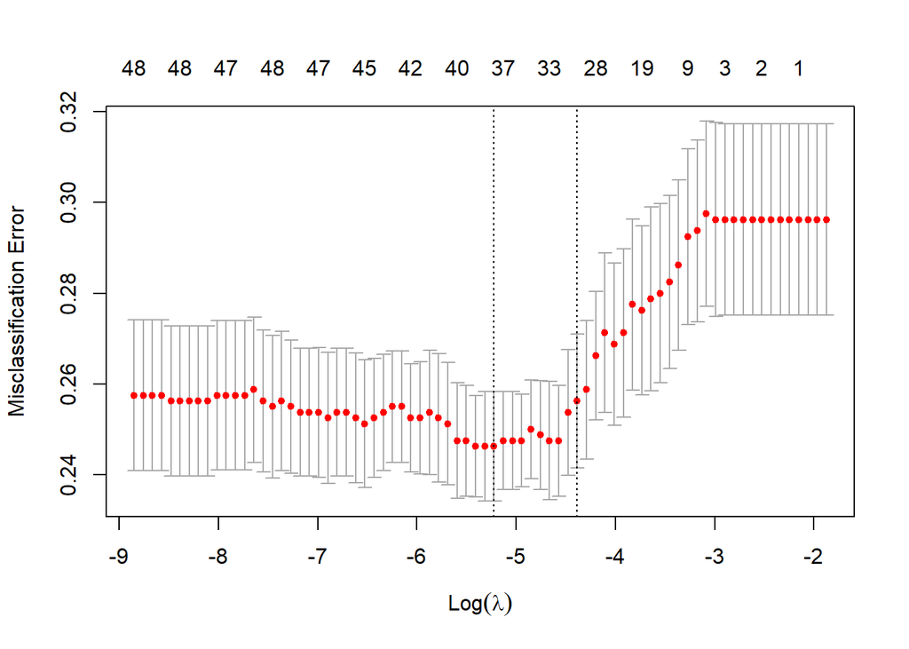

```r
# Implement LASSO
credit_lasso <- glmnet(x=credit_train_X, y=credit_train_Y, family = "binomial")

# Perform cross validation to determine shrinkage parameter
credit_lasso_cv<- cv.glmnet(x=credit_train_X, y=credit_train_Y, family = "binomial", type.measure = "class",k=5)
plot(credit_lasso_cv)
```

```r
# Coefficients with optimal lambda
coef(credit_lasso,s=credit_lasso_cv$lambda.min)
```

```r
# Prediction
pred_lasso_train <- predict(credit_lasso, newx=credit_train_X, s=credit_lasso_cv$lambda.1se, type = "response")

# Misclassification rate
misc <- table(credit_train$target, (pred_lasso_train > 1/6)*1, dnn=c("Truth","Predicted"))
(misc[1,2] + misc[2,1])/sum(misc)
```

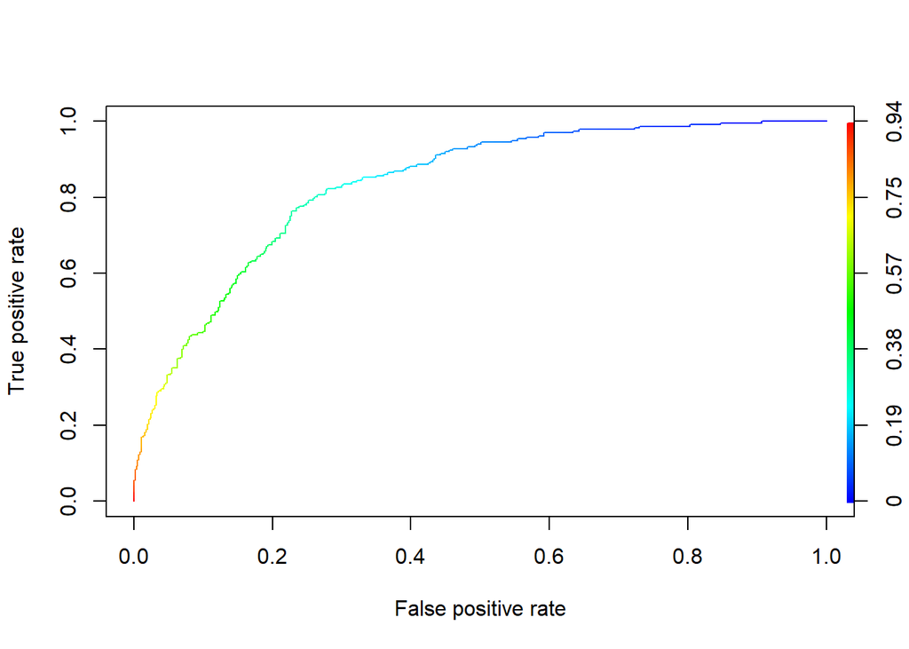

```r
# Fit final model (given by stepwise AIC)
model_lg_f <- glm(target ~ checking + history + purpose + installment + savings + foreign + other_inst + housing + credit + age + sex + liable + phone,family='binomial',credit_train)

# ROC Curve on final model (AIC)
pred_glm <- predict(model_lg_f, credit_train,type="response")
pred_lg <- prediction(pred_glm, credit_train$target)
perf <- performance(pred_lg, "tpr", "fpr")
plot(perf, colorize=TRUE)
```

```r
# Mean residual deviance
model_lg_f$deviance
```

```r
#Get the AUC
unlist(slot(performance(pred_lg, "auc"), "y.values"))
```

```r
# Asymmetric misclassification table
table(credit_train$target, (as.numeric(pred_glm > 1/6)*1)+1, dnn=c("Truth","Predicted"))
```

## 2.3 As in HW3, test the out-of-sample performance. Using final logistic linear model built from (i) on the 80% of original data, test with the remaining 20% testing data. (Try predict() function in R.) Report out-of-sample AUC and misclassification rate.

```r
# Predict test data using model built in (i)
pred_lg_f <- predict(model_lg_f,credit_test,type="response")

# AUC
pred_lg_final <- prediction(pred_lg_f, credit_test$target)
unlist(slot(performance(pred_lg_final, "auc"), "y.values"))
```

```r
# Asymmetric misclassification table
table(credit_test$target, as.numeric((pred_lg_f > 1/6)*1)+1, dnn=c("Truth","Predicted"))
```

## 2.4 Cross validation. Use 5-fold cross validation. (Please use cv.glm() function in R on the ORIGINAL 100% data.) Does (iv) yield similar answer as (iii)? Why? Make sure that you specify the right cost functions. Please try AUC and (asymmetric) misclassification rate.

```r
# Asymmetric cost function - misclassification rate
costfunc_misc  <- function(obs, pred.p){
    weight1 <- 5   # define the weight for "true=1 but pred=0" (FN)
    weight0 <- 1    # define the weight for "true=0 but pred=1" (FP)
    pcut <- 1/(1+weight1/weight0)
    c1 <- (obs==1)&(pred.p < pcut)    # count for "true=1 but pred=0"   (FN)
    c0 <- (obs==0)&(pred.p >= pcut)   # count for "true=0 but pred=1"   (FP)
    cost <- mean(weight1*c1 + weight0*c0)  # misclassification with weight
    return(cost) # you have to return to a value when you write R functions
}
```

```r
# Asymmetric cost function - AUC
costfunc_auc <- function(obs,pred) {
  pred_lg <- prediction(pred, obs)
  auc <- unlist(slot(performance(pred_lg, "auc"), "y.values"))
  return(auc)
}
```

```r
# 5-fold cross validation - AUC
set.seed(13748683)
credit_glm1<- glm(target~. , family=binomial, data=german_credit)
cv_result  <- cv.glm(data=german_credit, glmfit=credit_glm1, cost=costfunc_auc, K=5)
cv_result$delta[2]
```

```r
# 5-fold cross validation - misclassification rate
set.seed(13748683)
credit_glm1<- glm(target~. , family=binomial, data=german_credit)
cv_result  <- cv.glm(data=german_credit, glmfit=credit_glm1, cost=costfunc_misc, K=5)
cv_result$delta[2]
```

## 2.5 Fit a classification tree (CART) on the same data (the function rpart() is automatically adjusted for the cut-off probability so that you do not need to specify again); repeat the above step (iii). Please use plotcp() function and corresponding plot to prune the tree.

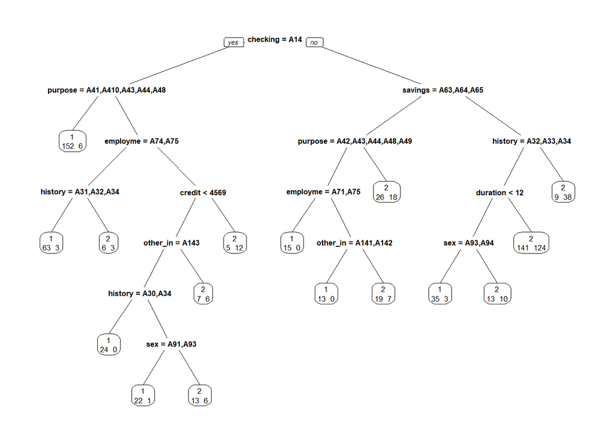

```r
# Fit CART model
credit_rparta <- rpart(formula = target ~ ., data = credit_train, method = "class", parms = list(loss=matrix(c(0,5,1,0), nrow = 2)))
prp(credit_rparta,digits = 4, extra = 1)
```

```r
credit_rparta

# Predict for test data
pred0 <- predict(credit_rparta, credit_test, type='class')
table(credit_test$target, pred0, dnn = c("True", "Pred"))
```

```r
# AUC
pred_prob <- predict(credit_rparta, credit_test, type = "prob")
pred = prediction(pred_prob[,2], credit_test$target)
slot(performance(pred, "auc"), "y.values")[[1]]
```

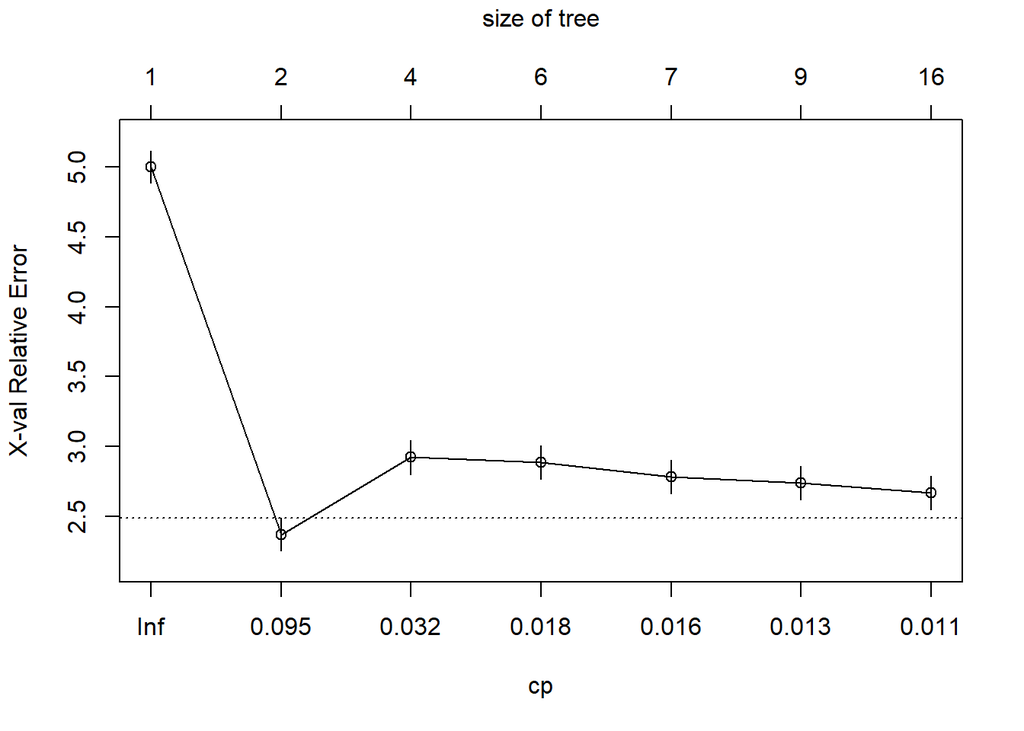

```r
# Plotting the tree
plotcp(credit_rparta)
```

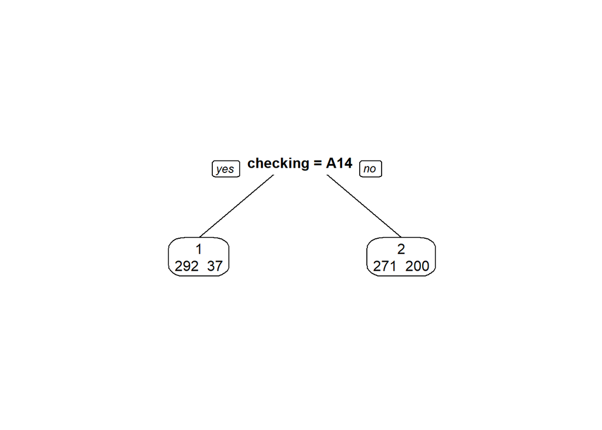

```r
# Prune the tree with cp=0.095
credit_rpart1 <- prune(credit_rparta,cp=0.095)
prp(credit_rpart1,digits = 4, extra = 1)
```

```r
# Prediction on pruned model
pred1 <- predict(credit_rpart1, credit_test, type='class')
table(credit_test$target, pred1, dnn = c("True", "Pred"))
```

## 2.7 Now repeat previous steps for another random sample. Do you get similar results? What’s your conclusion? Please provide detailed comparison tables.

### 2.7.1 Generalized Linear Regression Model

```r
# Create new train test split (90-10)
set.seed(13748683)
index <- sample(nrow(german_credit),nrow(german_credit)*0.90)
credit_train = german_credit[index,]
credit_test = german_credit[-index,]
```

```r
# Fit generalized linear regression model - logit link
model_l2 <- glm(target~., family=binomial(link='logit'), data=credit_train)

# Fit generalized linear regression model - probit link
model_p2 <- glm(target~., family=binomial(link='probit'), data=credit_train)

# Fit generalized linear regression model - complementary log-log link
model_c2 <- glm(target~., family=binomial(link='cloglog'), data=credit_train)
```

```r
# Compare coefficients
summary(model_l2)$coefficients
summary(model_p2)$coefficients
summary(model_c2)$coefficients
```

```r
# Misclassification rate
pred_l2 <- predict(model_l2)
pred_p2 <- predict(model_p2)
pred_c2 <- predict(model_c2)

misc_l2 <- table(credit_train$target, as.numeric((pred_l2 > 1/6)*1)+1, dnn=c("Truth","Predicted"))
misc_p2 <- table(credit_train$target, as.numeric((pred_p2 > 1/6)*1)+1, dnn=c("Truth","Predicted"))
misc_c2 <- table(credit_train$target, as.numeric((pred_c2 > 1/6)*1)+1, dnn=c("Truth","Predicted"))

(misc_l2[2,1] + misc_l2[1,2])/sum(misc_l)
(misc_p2[2,1] + misc_p2[1,2])/sum(misc_p)
(misc_c2[2,1] + misc_c2[1,2])/sum(misc_c)
```

### 2.7.2

```r
model_lg_n2 <- glm(target~1,family='binomial',credit_train)

# Stepwise selection using AIC
model_lg_aic2 <- step(model_lg_n2,scope=list(lower=model_lg_n2,upper=model_l2), direction= 'both')
```

```r
# Misclassification rate
pred_aic2 <- predict(model_lg_aic2)
table(credit_train$target, as.numeric((pred_aic2 > 1/6)*1)+1, dnn=c("Truth","Predicted"))
```

```r
# Stepwise selection using BIC
model_lg_bic2 <- step(model_lg_n2,scope=list(lower=model_lg_n2, upper= model_l2), direction ='both', k=log(nrow(credit_train)))
```

```r
# Misclassification rate
pred_bic2 <- predict(model_lg_bic2)
table(credit_train$target, as.numeric((pred_bic2 > 1/6)*1)+1, dnn=c("Truth","Predicted"))
```

```r
# Preparing data for LASSO
dummy <- model.matrix(~ ., data = german_credit)
credit_data_lasso <- data.frame(dummy[,-1])

credit_train_X = data.matrix(dplyr::select(credit_data_lasso, -target2)[index,])
credit_test_X = data.matrix(dplyr::select(credit_data_lasso, -target2)[-index,])
credit_train_Y = credit_data_lasso[index, "target2"]
credit_test_Y = credit_data_lasso[-index, "target2"]
```

```r
# Implement LASSO
credit_lasso <- glmnet(x=credit_train_X, y=credit_train_Y, family = "binomial")

# Perform cross validation to determine shrinkage parameter
credit_lasso_cv<- cv.glmnet(x=credit_train_X, y=credit_train_Y, family = "binomial", type.measure = "class")


# Coefficients with optimal lambda
coef(credit_lasso,s=credit_lasso_cv$lambda.min)
```

```r
# Prediction
pred_lasso_train <- predict(credit_lasso, newx=credit_train_X, s=credit_lasso_cv$lambda.1se, type = "response")

# Misclassification rate
misc <- table(credit_train$target, (pred_lasso_train > 1/6)*1, dnn=c("Truth","Predicted"))
(misc[1,2] + misc[2,1])/sum(misc)
```

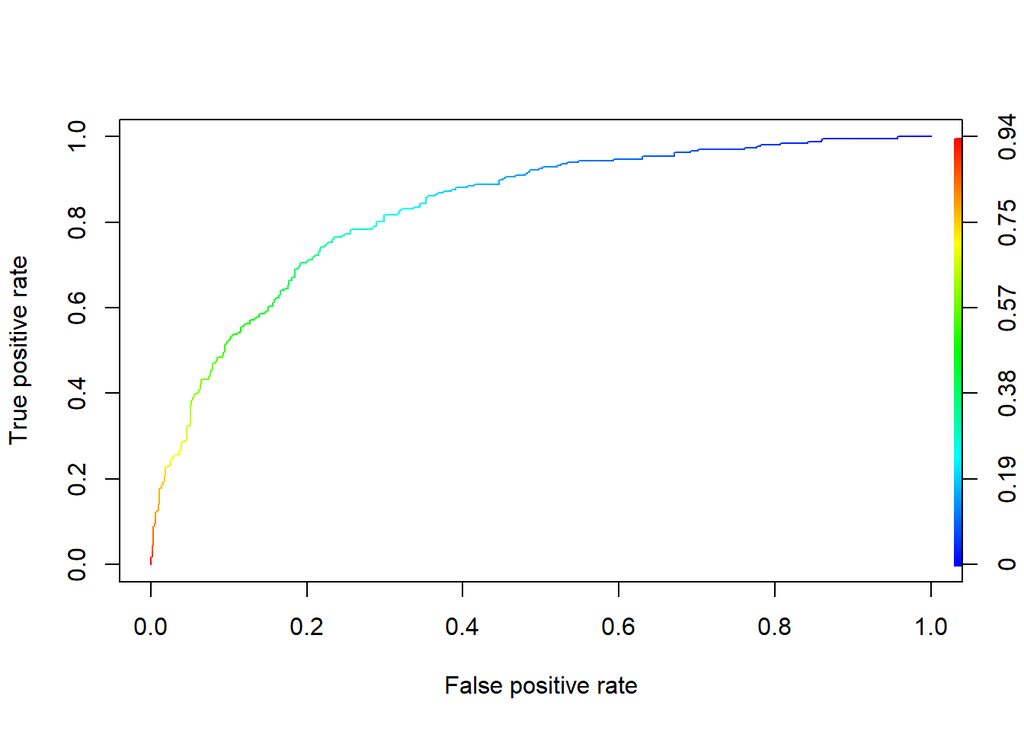

```r
# Fit final model
model_lg_f2 <- glm(target ~ checking + duration + history + purpose + savings + installment +                       debtors + housing + other_inst + foreign + credit + age +                                           sex,family='binomial',credit_train)

# ROC Curve on final model (AIC)
pred_glm <- predict(model_lg_f2, credit_train,type="response")
pred_lg <- prediction(pred_glm, credit_train$target)
perf <- performance(pred_lg, "tpr", "fpr")
plot(perf, colorize=TRUE)
```

```r
# Mean residual deviance
model_lg_f2$deviance
```

```r
#Get the AUC
unlist(slot(performance(pred_lg, "auc"), "y.values"))
```

```r
# Asymmetric misclassification table
table(credit_train$target, as.numeric((pred_glm > 1/6)*1)+1, dnn=c("Truth","Predicted"))
```

### 2.7.3 Out-of-sample misclassification rate

```r
pred_test_f <- predict(model_lg_f2,credit_test)
table(credit_test$target, as.numeric((pred_test_f > 1/6)*1)+1, dnn=c("Truth","Predicted"))
```

```r
# AUC
pred_lg <- prediction(pred_test_f, credit_test$target)
unlist(slot(performance(pred_lg, "auc"), "y.values"))
```

### 2.7.4 Cross Validation

```r
# 5-fold cross validation - AUC
credit_glm1<- glm(target~. , family=binomial, data=german_credit)
cv_result  <- cv.glm(data=german_credit, glmfit=credit_glm1, cost=costfunc_auc, K=5)
cv_result$delta[2]
```

```r
# 5-fold cross validation - misclassification rate
credit_glm1<- glm(target~. , family=binomial, data=german_credit)
cv_result  <- cv.glm(data=german_credit, glmfit=credit_glm1, cost=costfunc_misc, K=5)
cv_result$delta[2]
```

### 2.7.5 CART model

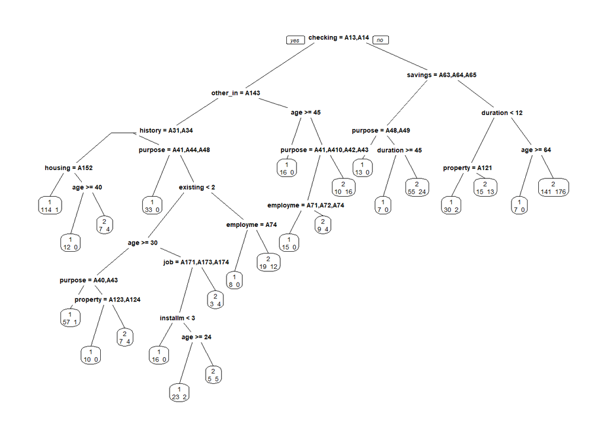

```r
# Fit CART model
credit_rparta <- rpart(formula = target ~ ., data = credit_train, method = "class", parms = list(loss=matrix(c(0,5,1,0), nrow = 2)))
prp(credit_rparta,digits = 4, extra = 1)
```

```r
credit_rparta

# Predict for test data
pred0 <- predict(credit_rparta, credit_test, type='class')
table(credit_test$target, pred0, dnn = c("True", "Pred"))
```

```r
# AUC
pred_prob <- predict(credit_rparta, credit_test, type = "prob")
pred = prediction(pred_prob[,2], credit_test$target)
slot(performance(pred, "auc"), "y.values")[[1]]
```

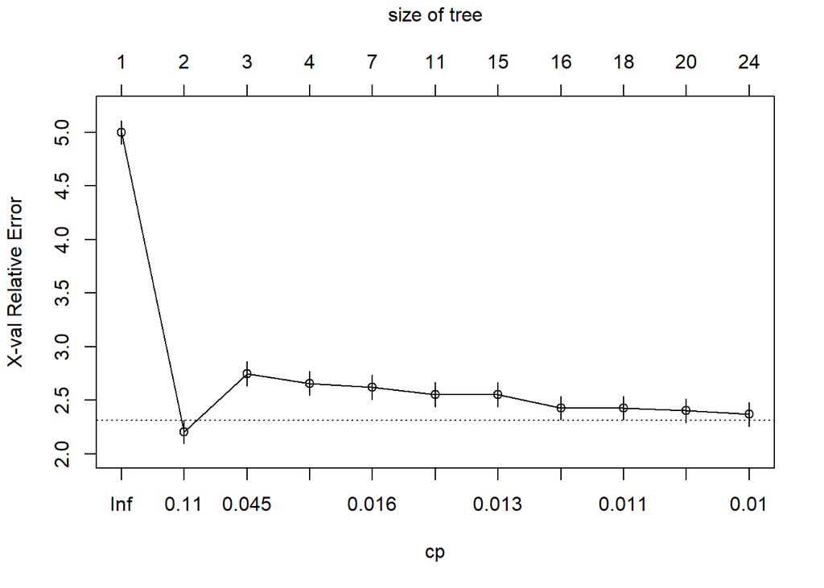

```r
# Plotting the tree
plotcp(credit_rparta)
```

```r
# Prune the tree with cp=0.011
credit_rpart1 <- prune(credit_rparta,cp=0.011)
```

```r
# Misclassification rate
pred_rpart1 <- predict(credit_rpart1,credit_test,type='class')
table(credit_test$target, pred_rpart1, dnn = c("True", "Pred"))
```

# Q.3 Monte Carlo Simulation Study (Logistic Regression)

## 3.1 Generate data with x1i~Unif(0,1), x2i =1 for i odd and x2i =0 for i even, and sample size n=500 for the following steps.

```r
# Generate data as per given instructions
set.seed(13748683)
n=500
m=100
x1 <- runif(n, min = 0, max = 1)
x2 <- c(1:n)
for (i in 1:n) {
    x2[i]=ifelse(x2[i]%%2==1,1,0)
}
```

## 3.2 Simulate the response vector y|x~Binary(p), where p= E(y|x), and logit(pi)= -1.1+5 x1i-0.4* x2i for a total of m=100 times. For each simulation, you have a new response vector y. Fit a logistic regression model for each simulation, save the necessary outputs.

```r
# Simulate data and record required observations
coef = data.frame(ncol=3)
auc = c()
dev = c()

for (i in 1:m) {
  p.logit <- ilogit(-1.1 + 5*x1 - 0.4*x2)
  y <- c()
  for (j in 1:n) {
      y[j] = rbinom(1,1,p.logit[j])
  }

  data_l <- data.frame('x1'=x1,'x2'=x2,'y'=y)
  data_l$y <- as.factor(data_l$y)
  data_l$x2 <- as.factor(data_l$x2)

  model <- glm(y~.,family='binomial',data_l)
  for (j in 1:3) {
    coef[i,j] = coef(model)[[j]]
  }

  dev[i] = deviance(model)

  pred <- predict(model, type='response')
  pred_lg <- prediction(pred, data_l$y)
  auc[i] = unlist(slot(performance(pred_lg, "auc"), "y.values"))

}
colnames(coef) <- c('Intercept','x1','x21')
```

## 3.3 Comparing estimates and parameters

```r
# Mean parameter estimate
int_hat <- mean(coef$Intercept)
beta1_hat <- mean(coef$x1)
beta2_hat <- mean(coef$x21)

int_hat
beta1_hat
beta2_hat
```

```r
# Estimation bias
int_bias <- int_hat - (-1.1)
beta1_bias <- beta1_hat - 5
beta2_bias <- beta2_hat - (-0.4)

int_bias
beta1_bias
beta2_bias
```

```r
# Variance
int_var <- mean(coef$Intercept - int_hat)
beta1_var <- mean(coef$x1 - beta1_hat)
beta2_var <- mean(coef$x21 - beta2_hat)

int_var
beta1_var
beta2_var
```

```r
# MSE
int_mse <- int_bias**2 + int_var
beta1_mse <- beta1_bias**2 + beta1_var
beta2_mse <- beta2_bias**2 + beta2_var

int_mse
beta1_mse
beta2_mse
```

## 2.4 Report the average estimated model mean residual deviance and average AUC over m simulations. Draw a box plot of model mean residual deviance; and a separate box plot of AUC.

```r
# Average residual deviance
mean(dev)
```

```r
# Average AUC
mean(auc)
```

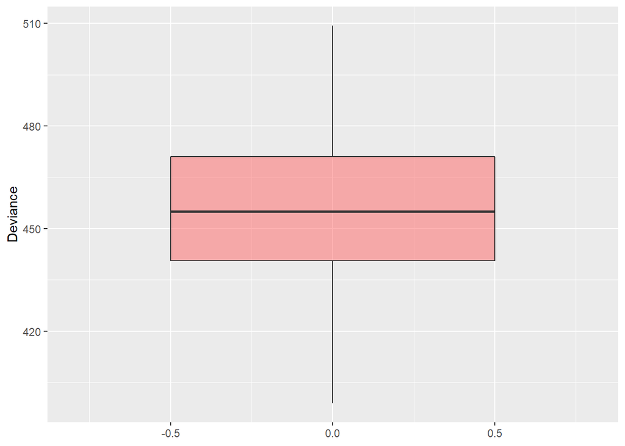

```r
# Box plot - residual deviance
dev_df <- data.frame('Deviance'=dev)
ggplot(dev_df, aes(y=Deviance)) +
  geom_boxplot(fill='#FF6666',outlier.colour = 'black',width=1,alpha=0.5) + xlim(-0.8,0.8)
```

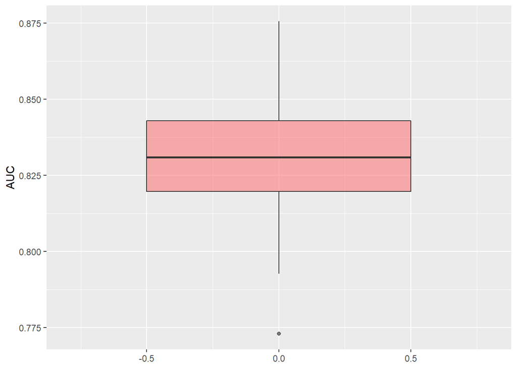

```r
# Box plot - auc
auc_df <- data.frame('AUC'=auc)
ggplot(auc_df, aes(y=AUC)) +
  geom_boxplot(fill='#FF6666',outlier.colour = 'black',width=1,alpha=0.5) + xlim(-0.8,0.8)
```

## 2.5 Please repeat i)-iv) with increased sample size n=5,000. What is your general conclusion when sample size increases?

### 2.5.1 Generate data

```r
set.seed(13748683)
n=5000
m=100
x1 <- runif(n, min = 0, max = 1)
x2 <- c(1:n)
for (i in 1:n) {
    x2[i]=ifelse(x2[i]%%2==1,1,0)
}
```

### 2.5.2 Simulate data

```r
set.seed(13748683)
coef = data.frame(ncol=3)
auc = c()
dev = c()

for (i in 1:m) {
  p.logit <- ilogit(-1.1 + 5*x1 - 0.4*x2)
  y <- c()
  for (j in 1:n) {
      y[j] = rbinom(1,1,p.logit[j])
  }

  data_l <- data.frame('x1'=x1,'x2'=x2,'y'=y)
  data_l$y <- as.factor(data_l$y)
  data_l$x2 <- as.factor(data_l$x2)

  model <- glm(y~.,family='binomial',data_l)
  for (j in 1:3) {
    coef[i,j] = coef(model)[[j]]
  }

  dev[i] = deviance(model)

  pred <- predict(model, type='response')
  pred_lg <- prediction(pred, data_l$y)
  auc[i] = unlist(slot(performance(pred_lg, "auc"), "y.values"))

}
colnames(coef) <- c('Intercept','x1','x21')
```

### 3.5.3

```r
# Mean parameter estimate
int_hat <- mean(coef$Intercept)
beta1_hat <- mean(coef$x1)
beta2_hat <- mean(coef$x21)

int_hat
beta1_hat
beta2_hat
```

```r
# Estimation bias
int_bias <- int_hat - (-1.1)
beta1_bias <- beta1_hat - 5
beta2_bias <- beta2_hat - (-0.4)

int_bias
beta1_bias
beta2_bias
```

```r
# Variance
int_var <- mean(coef$Intercept - int_hat)
beta1_var <- mean(coef$x1 - beta1_hat)
beta2_var <- mean(coef$x21 - beta2_hat)

int_var
beta1_var
beta2_var
```

```r
# MSE
int_mse <- int_bias**2 + int_var
beta1_mse <- beta1_bias**2 + beta1_var
beta2_mse <- beta2_bias**2 + beta2_var

int_mse
beta1_mse
beta2_mse
```

### 3.5.4 Average residual deviance and AUC

```r
# Average residual deviance
mean(dev)
```

```r
# Average AUC
mean(auc)
```

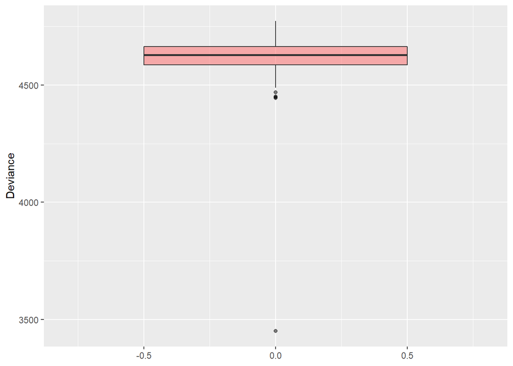

```r
# Box plot - residual deviance
dev_df <- data.frame('Deviance'=dev)
ggplot(dev_df, aes(y=Deviance)) +
  geom_boxplot(fill='#FF6666',outlier.colour = 'black',width=1,alpha=0.5) + xlim(-0.8,0.8)
```

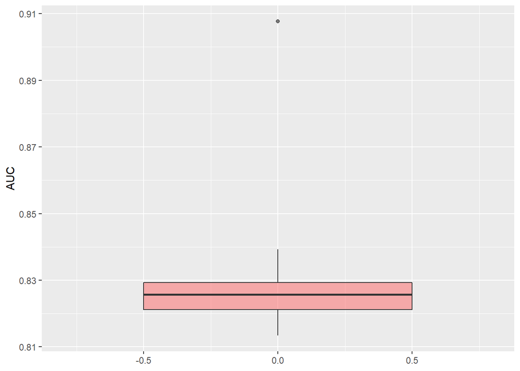

```r
# Box plot - AUC
auc_df <- data.frame('AUC'=auc)
ggplot(auc_df, aes(y=AUC)) +
  geom_boxplot(fill='#FF6666',outlier.colour = 'black',width=1,alpha=0.5) + xlim(-0.8,0.8)
```